# RMarkdown_Guide

Dataquest

2022-10-10

The shortcut to knit a document is Command + Shift + K

# First Level Header

## Second Level Header

### Bulleted and Numbered Lists

- List element 1
- List element 2
- List element 3
  - List item 3a
  - List item 3b

numbered lists:

1. Numbered list 1
2. Numbered list 2
3. Numbered list 3.The numbers auto-increment, don’t have to worry about renumbering!

combine numbered and unordered lists:

1. Numbered list 1
2. Numbered list 2
   - Item 1
   - Item 2

### Text Formatting

- Make text italic like *this* or *this*.
- Make text bold like **this** or **this**.
- Use `backticks` for code.
- Wrap a character to subscript in tildes (`~`). For example, `H~2~O` renders as H<sub>2</sub>O.
- Wrap a character to superscript in carets (`^`), like this: `R^2^` renders as R<sup>2</sup>.

### Links

Direct in-line links: https://rmarkdown.rstudio.com/.

Phrase links: RStudio’s [R Markdown page](https://rmarkdown.rstudio.com/).

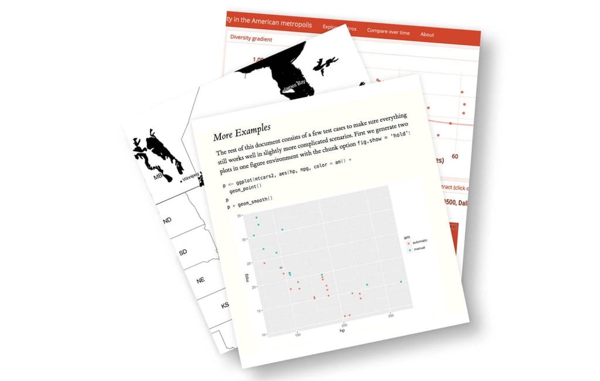

R Markdown image

### Insert a new code chunk with:

Command + Option + I

Before running code chunks it is often a good idea to restart your R session and start with a clean environment. Do this with Command + Shift + F10

To save time, it’s worth learning these shortcuts to run code:

- Run all chunks above the current chunk with Command + Option + P
- Run the current chunk with Command + Option + C or Command + Shift + Enter
- Run the next chunk with Command + Option + N
- Run all chunks with Command + Option + R or Command + A + Enter

## Inline Code

The `cars` dataset contains 50 rows and 2 columns.

```r
knitr::kable(head(cars),
             caption = "The First Few Rows of the Cars Dataset")
```

The First Few Rows of the Cars Dataset

| speed | dist |
| --- | --- |
| 4 | 2 |
| 4 | 10 |
| 7 | 4 |
| 7 | 22 |
| 8 | 16 |
| 9 | 10 |